# Práctica evaluable convoluciones

$Autor: Johana Cómbita Niño$

En esta práctica trabajaremos con modelos convolucionales, incluyendo algunos modelos residuales, para la predicción de la temperatura en superficie a partir de un conjunto de variables atmosféricas.

No se espera que los modelos aquí desarrollados sean capaces de hacer la predicción meteorológica de forma correcta ya que modelar esto con un modelo de deep learning no es una tarea sencilla. Si quereis saber más acerca de los modelos de deep learning aplicados al campo de la meteorología y el clima podeis echar un vistazo a [esta presentación](https://www.youtube.com/live/QgL-JmbYRp4?si=H_hH0zaBDpCXlKC1&t=2146) (minuto 35:36).

```python
import numpy as np
import math
import matplotlib.pyplot as plt
from datetime import datetime, timedelta
import keras
from keras import layers, models, regularizers
from sklearn.metrics import mean_squared_error
import tensorflow as tf
import random
```

Vamos a trabajar con los datos de **WeatherBench** [1,2], un dataset que busca proveer a investigadores de datos meteorologicos para construir modelos de predicción meterológica a partir de arquitecturas de deep learning. Podeis descargar los datos del siguiente enlace:

https://drive.google.com/drive/folders/1XnzY8hKWxifR65XFB3ErI_WZMLzzdR_n?usp=sharing

Una vez descargados, los podeis cargar de la siguiente forma (aseguraros de que el `PATH` hacia los ficheros es el correcto):

```python
x_data = np.load('./weatherbench_predictors.npy')
y_data = np.load('./weatherbench_predictand.npy')
```

El objetivo de esta práctica es, a partir de un conjunto de predictores (varias variables meteorológicas) predecir la temperatura en la superficie (para todo el globo). Los predictores (input) se corresponden con los datos en `x` mientras que el predictando (output) se corresponde con el `y`

```python
print(f'X shape: {x_data.shape} | Y shape: {y_data.shape}')
```

```
X shape: (14610, 32, 64, 6) | Y shape: (14610, 32, 64, 1)
```

La primera dimension se corresponde con el tiempo, vamos a tener datos para `14610` días. La segunda y tercera dimension (`32` y `64`) se corresponde con la latitud (altura) y longitud (anchura). Estas dos dimensiones se pueden interpretar de igual manera que el alto y ancho de las imágenes con las que hemos venido trabajando hasta ahora. La cuarta dimensión son el número de variables. Vamos a tener `6` predictores distintos, mientras que solo `1` variable para el predictando, la temperatura en superficie (la que vamos a predecir).

Como predictores vamos a utilizar las siguientes variables:

```python
predictor_vars = {0: 'Specific humidity at 850 hPa',
                  1: 'Air temperature at 850 hPa',
                  2: 'Geopotential at 850 hPa',
                  3: 'U wind component (10m)',
                  4: 'V wind component (10m)',
                  5: 'Total cloud cover'}
```

Este diccionario mapea cada dimensión del objeto `x` con la variable a la que corresponde (e.g., el total cloud cover se corresponde con los datos `x[:, :, :, 5]`)

Podemos hacer algo similar para el predictando, aunque en este caso solo vamos a tener una variable:

```python
predictand_vars = {0: 'Surface (2m) temperature'}
```

Para definir el tiempo podemos hacer algo similar. Los datos van a cubrir datos diarios desde el 1979 hasta el 2018. En este caso, por ejemplo, el 01/01/1979 se corresponde con los datos `x[0, :, :, :]`:

```python
start_time = datetime(1979, 1, 1, 12, 0)
end_time   = datetime(2018, 12, 31, 12, 0)
time_step  = timedelta(days=1)

temporal_dims = {i: start_time + timedelta(days=i) for i in range(0, (end_time - start_time).days + 1)}
```

A continuación, para cada una de las variables del predictor, vamos a dibujar su media temporal:

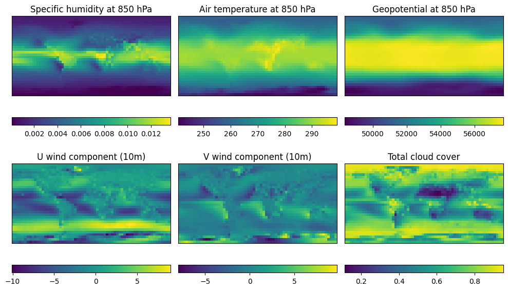

```python
def plot_mean_subplots(data, variable_dims, figsize):

    keys = list(variable_dims.keys())
    n_vars = len(keys)

    n = math.ceil(math.sqrt(n_vars))

    if n == 1:
        fig, axes = plt.subplots(n, n, figsize=figsize)
        axes = [axes]
    else:
        fig, axes = plt.subplots(n-1, n, figsize=figsize)
        axes = axes.flatten()

    for idx, key in enumerate(keys):
        arr = data[:, :, :, key]
        mean_val = np.mean(arr, axis=0)
        im = axes[idx].imshow(mean_val, origin='lower')
        axes[idx].set_title(variable_dims[key])
        axes[idx].set_xticks([])
        axes[idx].set_yticks([])
        fig.colorbar(im, ax=axes[idx], orientation='horizontal')

    for i in range(n_vars, len(axes)):
        axes[i].axis('off')

    plt.tight_layout()
    plt.show()

plot_mean_subplots(data=x_data, variable_dims=predictor_vars, figsize=(10, 6))
```

Estas variables se suelen considerar informativas para la predicción meteorológica, a continuación podes encontrar una breve explicación de lo que cada una de ellas representa:

- **Specific humidity at 850 hPa**: La humedad específica a 850 hPa mide la cantidad de vapor de agua por kilogramo de aire a esa altitud, aproximadamente 1.5 km sobre el nivel del mar. Este valor es útil para comprender la humedad en la atmósfera baja, lo que puede influir en la formación de nubes y en la precipitación.
- **Air temperature at 850 hPa**: La temperatura del aire a 850 hPa indica el calor presente en la atmósfera a aproximadamente 1.5 km sobre el nivel del mar. Este valor es importante para evaluar la estabilidad atmosférica y la formación de fenómenos meteorológicos.
- **Geopotential at 850 hPa**: El geopotencial a 850 hPa indica la altura (en metros) a la que se encuentra ese nivel de presión atmosférica, considerando la variación de la gravedad. Este valor es útil para analizar la estructura vertical de la atmósfera y la circulación de los sistemas meteorológicos.
- **U and V wind components (10m)**: La componente U del viento a 10 m indica la velocidad en dirección este-oeste, y la componente V en dirección norte-sur. Juntas, describen la dirección e intensidad del viento a nivel de la superficie.
- **Total cloud cover**: La cobertura total de nubes indica la fracción del cielo que está cubierta por nubes, generalmente expresada en porcentaje. Este valor es clave para entender la cantidad de radiación solar que puede alcanzar la superficie terrestre y las condiciones climáticas generales.

Visualizemos ahora la variable que queremos predecir a partir de estos predictors, la temperatura en superficie:

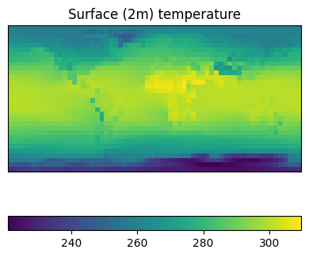

```python
plot_mean_subplots(data=y_data, variable_dims=predictand_vars, figsize=(4, 4))
```

Es importante notar la diferencia entre lo que estamos intentando aprender con el modelo deep learning ahora en comparación con el resto de prácticas. En este caso estamos ante un problema de regresión (no clasificación). El output del modelo va a ser una imagen, no un vector, ya que queremos predecir la temperatura en superficie para un dia para todo el globo (la imagen de la celda superior). Por ello la salida de nuestro modelo (para un día concreto) va a ser una matriz con dimensión `(1, 32, 64, 1)`.

**Ejercicio 1** (0.5 puntos): Crea una partición de train y otra de test a partir de los datos `x` e `y`. Las proporciones deben de ser del 80% y 20%, respectivamente. ¿Crees que la forma adecuada de hacer esta partición es seleccinando de forma aleatoria las muestras que van a cada conjunto? Si se te ocurre otra que encaje más con el problema de predicción meterológica implementala.

```python
# tamano de los datos
n_samples = x_data.shape[0]
# tamaño de train
train_size = int(n_samples * 0.8)

# particionar los datos en train y test teniendo en cuenta el tiempo
x_train = x_data[:train_size, :, :, :]
y_train = y_data[:train_size, :, :, :]
x_test = x_data[train_size:, :, :, :]
y_test = y_data[train_size:, :, :, :]

print(f"x_train shape: {x_train.shape} | y_train shape: {y_train.shape}")
print(f"x_test  shape: {x_test.shape}  | y_test  shape: {y_test.shape}")
```

```
x_train shape: (11688, 32, 64, 6) | y_train shape: (11688, 32, 64, 1)
x_test  shape: (2922, 32, 64, 6)  | y_test  shape: (2922, 32, 64, 1)
```

Para problemas de series temporales o datos con dependencia temporal, como es el caso de predicción meteorológica, no es recomendable mezclar días aleatoriamente entre entrenamiento y test. Esto se debe a que si se mezclan datos futuros en el conjunto de entrenamiento se estaría introduciendo información que el modelo no debería conocer. De esta forma, la partición cronológica debe ser primero entrenamiento y luego test en el eje temporal, lo cual refleja una mejor situación real de predicción, donde el modelo aprende de datos pasados y predice datos futuros que nunca ha visto.

**Ejercicio 2** (1 punto): Normaliza los predictores. Recuerda que las imagenes se normalizan dividiendo por 255 porque es es su rango natural, pero en este caso no es así. Recuerda que la formula de la normalización *min-max* es:

$x_{\text{norm}} = \frac{x - x_{\text{min}}}{x_{\text{max}} - x_{\text{min}}}$

¿Crees que en este caso habría que calcular el mínimo y máximo individualmente para cada pixel y variable o no?

```python
x_train_n = np.empty_like(x_train, dtype=np.float32)
x_test_n = np.empty_like(x_test, dtype=np.float32)

for var_idx in range(x_train.shape[-1]):
    # seleccion de la variable
    variable_data_train = x_train[..., var_idx]
    variable_data_test = x_test[..., var_idx]

    # calculo max y min con train
    min_val = np.min(variable_data_train)
    max_val = np.max(variable_data_train)

    # normalizacion
    if max_val == min_val:
        x_train_n[..., var_idx] = 0
        x_test_n[..., var_idx] = 0
    else:
        x_train_n[..., var_idx] = (variable_data_train - min_val) / (max_val - min_val)
        x_test_n[..., var_idx] = (variable_data_test - min_val) / (max_val - min_val)

# mismas dimensiones pero normalizado en 0-1
print(x_train_n.shape, x_test_n.shape)
```

```
(11688, 32, 64, 6) (2922, 32, 64, 6)
```

Si se calcula el min y max para cada pixel y variable se pierde la coherencia entre los valores de diferentes píxeles, debido a que cada píxel tendría su propia escala, y un valor alto en un píxel podría ser un valor bajo en otro píxel tras la normalización si sus rangos originales fuesen diferentes. Como resultado, el modelo podría interpretar que ciertas regiones del mapa tienen características distintas simplemente por cómo han sido escaladas, no por diferencias reales en los datos. Esto introduciría ruido y dificultaría el aprendizaje de patrones espaciales consistentes.

Por el contrario, al normalizar por variable, se consideran todos los píxeles y todas las fechas de cada variable, lo que permite mantener una escala uniforme en todo el dominio espacial y temporal; es decir, se calcula un único valor mínimo y máximo para cada canal (variable meteorológica), y se aplica la normalización min-max de forma global a ese canal. De esta forma, cada variable queda escalada de manera coherente, lo que facilita el entrenamiento del modelo y permite comparaciones significativas entre regiones.

**Ejercicio 3** (0.5 puntos): Normalmente en los modelos de deep learning se suele normalizar la entrada (predictores en nuestro caso) pero no la salida, ¿por qué crees que es esto?

En problemas de deep learning, es muy habitual normalizar la entrada porque cada variable (predictores) puede tener rangos de valores muy diferentes, donde la normalización facilita la optimización del modelo, ya que permite que el gradiente fluya de manera más estable cuando todas las variables están en escalas similares.

Por otra parte, la salida no se normaliza (en este caso la temperatura en superficie) principalmente porque no presentan el mismo problema de escalas diversas que las variables predictoras. En este caso es una única variable que oscila dentro de un rango definido, como es el caso de la temperatura en Kelvin; mientras que las variables de entrada podrían incluir humedad específica, velocidad del viento, geopotencial, entre otras, cada una con rangos diferentes. Adicionalmente, mantener la salida en su escala original facilita su interpretación y permite compararla directamente con valores físicos reales o de referencia.

**Ejercicio 4** (1 punto): Define un primer modelo con una arquitectura compuesta unicamente de capas densas. Razona tu elección de activación en la última capa. Razona tu elección de numero de neuronas de salida. ¿Por qué crees que en este caso una red convolucional encaja mejor que una densa?

Es importante recordar que queremos que la salida del modelo tenga la misma dimensión que nuestra `y` (predictando), por ello al final del modelo vamos a tener que añadir una capa del estilo:

`layers.Reshape((y_train.shape[1:]))`

¿Por qué crees que en este caso deberíamos utilizar capas convolucionales en vez de densas?

Una capa densa espera un vector como entrada, pero los datos meteorológicos que se están utilizando en este ejercicio tienen una estructura multidimensional, donde cada x tiene una forma (32,64,6), es decir es una imagen de 32x64 con 6 variables meteorológicas. La capa densa conecta cada neurona de entrada con cada neurona de salida, donde cada entrada es un vector, por lo cual es necesario aplanar la entrada (entrada multidimensional en una sola dimensión). Esto es posible hacer en la construcción del modelo con la función flatten.

A continuación, se define el modelo aplanando la entrada y con 2 capas densas, una de 1024 y otra de 512. El diseño se establece de esta manera para garantizar una estructura de embudo, donde la primera capa aprende representaciones complejas de los datos de entrada, y la segunda es una capa más pequeña para ir resumiendo y refinando la información para la salida; ambas con una función de activación ReLu, debido a que es muy eficiente en redes neuronales por evitar el problema del gradiente desaparecido. Luego se agrega la capa de salida con el número de neuronas de los valores esperados, que en este caso es el producto del tamaño de Y, donde cada salida es una imagen 2D de tamaño 32 × 64 (latitud × longitud) con un canal que representa la temperatura. Para que la salida final sea una imagen con forma (32, 64, 1), el vector con 2048 valores (32x 64x 1 =2048) se transforma en esa estructura con la función Reshape. Esto quiere decir que, cada una de esas 2048 neuronas representa la predicción de temperatura para un punto geográfico.

Finalmente, como se trata de un problema de regresión y no de clasificación, no se usan funciones como softmax y sigmoid, sino linear. Como la temperatura es una magnitud continua que puede estar en un rango, esta función de activación permite que el modelo pueda predecir cualquier valor real dentro de ese rango sin limitarlo.

```python
# Tamaños base
input_shape = x_train_n.shape[1:]
output_shape = y_train.shape[1:]
output_neurons = np.prod(output_shape)

# Definicion del modelo
dense_model = models.Sequential()
dense_model.add(layers.Input(shape=input_shape))
dense_model.add(layers.Flatten()) # se aplana a 32*64*6 = 12288
dense_model.add(layers.Dense(1024, activation='relu'))
dense_model.add(layers.Dense(512, activation='relu'))
dense_model.add(layers.Dense(output_neurons, activation='linear'))
dense_model.add(layers.Reshape(output_shape))

dense_model.summary()
```

```
Model: "sequential"
_________________________________________________________________
 Layer (type)                Output Shape              Param #
=================================================================
 flatten (Flatten)           (None, 12288)             0

 dense (Dense)               (None, 1024)              12583936

 dense_1 (Dense)             (None, 512)               524800

 dense_2 (Dense)             (None, 2048)              1050624

 reshape (Reshape)           (None, 32, 64, 1)         0

=================================================================
Total params: 14159360 (54.01 MB)
Trainable params: 14159360 (54.01 MB)
Non-trainable params: 0 (0.00 Byte)
_________________________________________________________________
```

Aunque una red densa puede funcionar, no es la opción más adecuada cuando se trabaja con datos espaciales como en este caso. Al aplanar la entrada, se pierde la estructura espacial de los datos, lo que impide capturar relaciones locales entre píxeles, como la influencia de zonas vecinas en la temperatura. Además, las capas densas generan una gran cantidad de parámetros, lo que puede provocar sobreajuste y dificultades de escalabilidad.

Por el contrario, las redes convolucionales preservan la estructura espacial, usan filtros que detectan patrones locales y comparten pesos, lo que reduce significativamente el número de parámetros. Esto permite capturar patrones meteorológicos relevantes de forma más eficiente y con menor riesgo de sobreajuste.

Recordemos que en este caso se tiene una entrada con una estructura espacial, las variables atmosféricas están organizadas en canales, y puede ser necesario identificar relacionales espaciales (la temperatura en un punto esté influida por sus regiones vecinas). En este sentido, las redes convolucionales permiten capturar mejor este tipo de estructuras.

**Ejercicio 5** (1 punto): Diseña un modelo convolucional sencillo, utilizando solo `layers.Conv2D`. ¿Qué diferencia hay en el número de parametros con respecto al modelo denso? Entrenalo por varias épocas. Justifica tu elección de función de pérdida.

En este caso no necesitamos recurrir a `layers.Reshape` ya que no utilizamos capas densas. Lo unico que tenemos que hacer es asegurarnos de que las capas convolucionales no reducen la dimensión espacial a través del argumento `padding='same'`, de esta forma solo tenemos que reducir el número de *filters* para que la salida de la última capa del modelo tenga la dimensión `(:, 32, 64, 1)`.

Se hace el diseño del modelo convolucional con una entrada, 2 capas y una salida. La entrada se define como un mapa de 32×64 píxeles con 6 canales (variables meteorológicas). En la primera capa se define un filtro de 32, con un tamaño de kernel 3x3, padding = same y función de activación ReLu. Para la segunda capa se establece un filtro de 16 con el resto de los parámetros de la capa anterior. En la última capa se establece un filtro igual a 1 y una función de activación linear. Con el filtro igual a 1 se busca generar una única imagen con salida (32, 64, 1), es decir, una predicción de temperatura por punto.

Es importante mencionar que, se usaron 32 y 16 filtros porque se trata de una arquitectura sencilla que busca detectar patrones espaciales relevantes, comenzando con más filtros en la primera capa para captar características generales y se reduce en la segunda para refinar la información. Cada filtro es como una plantilla que almacena un tipo de patrón espacial (como cambios bruscos, nubes, frentes, etc.). Al usar 32 filtros, se le pide a la red que en la primera capa detecte 32 tipos diferentes de patrones, y en la segunda capa 16 filtros con características más específicas.

Por su parte, el tamaño del kernel (3x3) es un estándar muy utilizado en redes neuronales profundas, debido a que permite captar patrones locales sin excesivo coste computacional. En cuanto a la función de activación, ReLU se utiliza en las capas ocultas porque es eficiente, evita el gradiente desaparecido, y permite introducir no linealidad. En cambio, linear se usa en la capa final porque el problema es de regresión, y esta activación permite que el modelo prediga cualquier valor real de un rango.

```python
seed = 703
random.seed(seed)
np.random.seed(seed)
tf.random.set_seed(seed)

conv_model = models.Sequential()
conv_model.add(layers.Input(shape=(32, 64, 6)))

conv_model.add(layers.Conv2D(filters=32, kernel_size=(3, 3), padding='same', activation='relu'))
conv_model.add(layers.Conv2D(filters=16, kernel_size=(3, 3), padding='same', activation='relu'))
conv_model.add(layers.Conv2D(filters=1, kernel_size=(3, 3), padding='same', activation='linear'))

conv_model.summary()
```

```
Model: "sequential_1"
_________________________________________________________________
 Layer (type)                Output Shape              Param #
=================================================================
 conv2d (Conv2D)             (None, 32, 64, 32)        1760

 conv2d_1 (Conv2D)           (None, 32, 64, 16)        4624

 conv2d_2 (Conv2D)           (None, 32, 64, 1)         145

=================================================================
Total params: 6529 (25.50 KB)
Trainable params: 6529 (25.50 KB)
Non-trainable params: 0 (0.00 Byte)
_________________________________________________________________
```

Al comparar ambos modelos, se observa que el modelo convolucional requiere muchos menos parámetros que el modelo denso, lo cual se debe a que en la red densa cada neurona se conecta con todas las neuronas de la capa anterior, lo que genera un número muy elevado de parámetros. Por ejemplo, en el modelo denso la entrada aplanada de 12288 elementos, al conectarse con una capa de 1024 neuronas, produce más de 12 millones de parámetros solo en esa capa. En cambio, en el modelo convolucional, cada filtro actúa localmente sobre pequeñas regiones de la imagen, y los pesos se comparten a lo largo de toda la entrada; permitiendo capturar patrones espaciales manteniendo un número de parámetros mucho menor.

Además, es importante recordar que los modelos convolucionales son más adecuados para datos espaciales, ya que preservan la estructura de la entrada, capturan relaciones locales y escalan mejor en eficiencia. Por este motivo, son muy útiles en tareas con datos georreferenciados como los meteorológicos.

Luego, se entrena el modelo por 20 épocas, entableciendo lotes de 32 para mejorar la eficiencia en el entrenamiento, y se usa el 20% del conjunto de entrenamiento para validación. Es importante mencionar que se usó mse (mean squared error) como función de pérdida porque se trata de un problema de regresión donde se quiere predecir valores continuos, como lo es la temperatura. Además, se estableció el optimizador Adam debido a que es eficaz en redes convolucionales.

```python
conv_model.compile(optimizer='adam', loss='mse', metrics=['mse'])
history = conv_model.fit(x_train_n, y_train, epochs=20, batch_size=32, validation_split=0.2)
```

**Ejercicio 6** (1 punto): Calcula las predicciones en el periodo de test y evalua los resultados utilizando alguna métrica de evaluación (por ejemplo RMSE o MAE). Si es posible, calcula también estas métricas a nivel de pixel, de forma que podamos visualizar una imagen del globo en la que cada pixel sea el resultado de aplicar esa métrica sobre ese pixel.

Por las razones explicadas en puntos anteriores, se usa el modelo entrenado de convoluciones para predecir sobre el conjunto de test.

```python
y_pred = conv_model.predict(x_test_n)
```

Luego se evalúa la predicción con la métrica MSE, teniendo en cuenta que es un problema de regresión.

```python
# calculo de mse
mse = conv_model.evaluate(x_test_n, y_test)[1]
print(f'MSE: {mse}')
```

```
MSE: 24.017911911010742
```

```python
#Raíz del Error Cuadrático Medio (RMSE)
rmse_global = mean_squared_error(y_test.flatten(), y_pred.flatten(), squared=False)

print(f"RMSE: {rmse_global}")
```

```
RMSE: 4.900805950164795
```

Es importante mencionar que el Error Cuadrático Medio (MSE) está en Kelvin^2, siendo un resultado que no es fácilmente interpretable. Por tal razón, se calcula la Raíz del Error Cuadrático Medio (RMSE) que es la raíz del MSE, haciendo que dé como resultado la misma unidad que la variable (°K), facilitando la interpretación. En este caso, se tiene que RMSE es aproximadamente 4.9, lo que significa que en promedio la predicción se desvía unos 4.9°K de la realidad.

A continuación, se visualiza la predicción del día 0 versus la real para validar que el modelo está aprendiendo algo coherente.

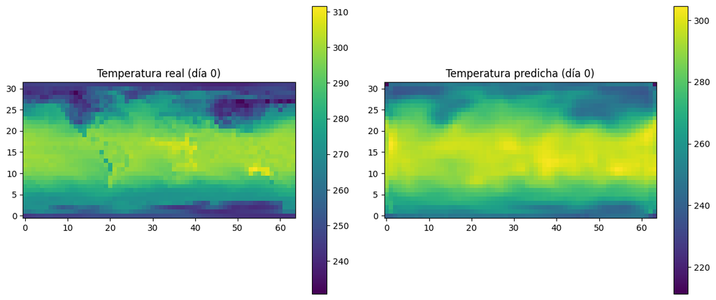

```python
dia = 0

plt.figure(figsize=(12, 5))

# Temperatura real
plt.subplot(1, 2, 1)
plt.imshow(y_test[dia, :, :, 0], origin='lower')
plt.title("Temperatura real (día 0)")
plt.colorbar()

# Temperatura predicha
plt.subplot(1, 2, 2)
plt.imshow(y_pred[dia, :, :, 0], origin='lower')
plt.title("Temperatura predicha (día 0)")
plt.colorbar()

plt.tight_layout()
plt.show()
```

En la gráfica se puede observar que existe una estructura similar, siguiendo un patrón coherente en la predicción, resaltando los colores de la temperatura de superficie de manera similar a la imagen real. Sin embargo, se observa que puede mejorar debido a que en la predicción no se detecta bien extremos, suavizando variaciones y generalizando un poco, especialmente en zonas geográficas que pueden tener características diferentes. En este sentido, se tiene un modelo que reconoce un patrón global pero pierde el contraste en ciertas zonas.

Seguidamente se calcula la métrica a nivel de píxel, donde la idea es obtener una imagen en la cual cada píxel sea la métrica calculada a lo largo de todos los días del conjunto de test. La idea es mantener la forma (32×64), para que cada píxel en la malla corresponde a un punto geográfico (celda lat-lon), y así obtener un mapa de predicciones que cubre toda la rejilla global y compararlo directamente con los datos reales.

```python
# Cálculo del error cuadrático medio a lo largo del eje 0
pixel_mse = np.mean((y_test - y_pred)**2, axis=0)
pixel_rmse = np.sqrt(pixel_mse)

# Se quita dimensión final para que quede 32x64
pixel_rmse = np.squeeze(pixel_rmse)

print("pixel_rmse shape:", pixel_rmse.shape)
```

```
pixel_rmse shape: (32, 64)
```

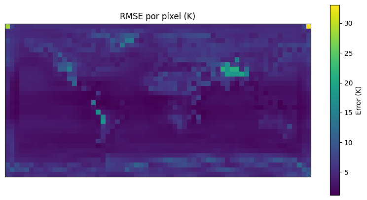

```python
plt.figure(figsize=(10, 5))
plt.imshow(pixel_rmse, origin='lower')
plt.title("RMSE por píxel (K)")
plt.colorbar(label="Error (K)")
plt.xticks([])
plt.yticks([])
plt.show()
```

En este mapa, cada valor indica cuánto se desvió en promedio la predicción con respecto al valor real en cada localización geográfica. En la imagen se observa que en ciertas zonas los colores son más intensos, lo que significa que en esos puntos el error es mayor. En términos generales se puede observar un buen desempeño, sin embargo, el error es un poco más alto en regiones montañosas o con características geográficas especiales, como puede ser la cordillera de los Andes y la cordillera del Himalaya.

**Ejercicio 7** (0.5 puntos): Escribe una función que nos permita comparar la predicción para un día concreto contra el valor en el periodo de test. No es necesario indexar los datos con el día, basta con hacerlo a través de los índices (`0:14610`).

Se crea modelo capaz de predecir y comparar la predicción del día establecido, generando una salida visual de la temperatura real, predicha y la diferencia.

```python
def compare_prediction(day_index, x_data, y_data, model):
    """
    day_index (int): índice del día a comparar
    x_data (array): datos de entrada de test
    y_data (array): datos de salida verdaderos de test
    model (keras.Model): modelo entrenado

    Esta función muestra la temperatura real vs la predicha para un día en concreto.
    """

    # predicción (y_pred) para el día elegido
    x_sample = x_data[day_index:day_index + 1]
    y_pred = model.predict(x_sample)

    #Se obtiene la temperatura real de ese día
    y_true = y_data[day_index]

    # Ajuste de dimensiones para graficar
    y_pred_2d = np.squeeze(y_pred[0], axis=-1)
    y_true_2d = np.squeeze(y_true, axis=-1)

    # calculo de mapa de diferencias
    diff_2d = y_pred_2d - y_true_2d

    # Visualización
    plt.figure(figsize=(14, 4))

    # Temperatura real
    plt.subplot(1, 3, 1)
    plt.imshow(y_true_2d, origin='lower')
    plt.title(f"Temperatura Real (day={day_index})")
    plt.colorbar(label='K')
    plt.xticks([])
    plt.yticks([])

    # Temperatura predicha
    plt.subplot(1, 3, 2)
    plt.imshow(y_pred_2d, origin='lower')
    plt.title("Temperatura Predicha")
    plt.colorbar(label='K')
    plt.xticks([])
    plt.yticks([])

    # Diferencia (pred - real)
    plt.subplot(1, 3, 3)
    plt.imshow(diff_2d, origin='lower', cmap='bwr')
    plt.title("Diferencia (Pred - Real)")
    plt.colorbar(label='K')
    plt.xticks([])
    plt.yticks([])

    plt.tight_layout()
    plt.show()
```

Se aplica la función al mismo día que se analizó en el ejercicio anterior para validar su correcto funcionamiento.

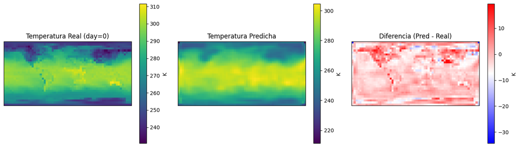

```python
compare_prediction(day_index=0, x_data=x_test_n, y_data=y_test, model=conv_model)
```

Los resultados de la gráfica coinciden con las generadas en el punto anterior, lo cual valida el correcto funcionamiento de la función. Por otra parte, se genera otra gráfica que muestra la diferencia entre el valor predicho y el real, donde las zonas de color rojo en el mapa resaltan donde se sobreestima la predicción de la temperatura y en color azul donde se subestima. Este coincide con el análisis realizado anteriormente, donde es posible observar que hay un mayor error en zonas montañosas o latitudes extremas (mayor diferencia). En términos generales se observa que el modelo tiende a sobreestimar en la predicción.

**Ejercicio 8** (1 punto): Diseña y entrena un modelo convolucional más complejo a partir de los elementos vistos en la práctica anterior (por ejemplo con Batch Normalization). Si es necesario modifica el algoritmo de optimización o añade alguna forma de regularización.

Se hace el diseño de un modelo convolucional con 4 capas ocultas y una de salida. Las primeras 2 tienen 32 filtros con regularización L2 para evitar el sobreajuste, penalizando los pesos grandes en la función de costo. También se añade regularización con dropout entre la segunda y tercera convolución, para eliminar aleatoriamente el 30% de las neuronas durante el entrenamiento, obligando a la red a no depender de conexiones específicas y a distribuir mejor la representación para evitar el sobreajuste. Además, las capas 3 y 4 tienen 16 y 8 filtros respectivamente, para el aprendizaje de características más específicas; y se mantienen los parámetros de padding, kernel size y funciones de activación descritos en el modelo anterior.

```python
seed = 703
random.seed(seed)
np.random.seed(seed)
tf.random.set_seed(seed)

#modelo
conv_model_c = models.Sequential()
conv_model_c.add(layers.Input(shape=(32, 64, 6)))

conv_model_c.add(layers.Conv2D(filters=32, kernel_size=(3,3), padding='same', kernel_regularizer=regularizers.l2(1e-3), use_bias=False))
conv_model_c.add(layers.BatchNormalization())
conv_model_c.add(layers.ReLU())

conv_model_c.add(layers.Conv2D(filters=32, kernel_size=(3,3), padding='same', kernel_regularizer=regularizers.l2(1e-3), use_bias=False))
conv_model_c.add(layers.BatchNormalization())
conv_model_c.add(layers.ReLU())
conv_model_c.add(layers.Dropout(0.3))

conv_model_c.add(layers.Conv2D(filters=16, kernel_size=(3,3), padding='same', kernel_regularizer=regularizers.l2(1e-3), use_bias=False))
conv_model_c.add(layers.BatchNormalization())
conv_model_c.add(layers.ReLU())

conv_model_c.add(layers.Conv2D(filters=8, kernel_size=(3,3), padding='same', kernel_regularizer=regularizers.l2(1e-3), use_bias=False))
conv_model_c.add(layers.BatchNormalization())
conv_model_c.add(layers.ReLU())

conv_model_c.add(layers.Conv2D(filters=1, kernel_size=(3,3), padding='same', activation='linear'))

conv_model_c.summary()
```

```
Model: "sequential_2"
_________________________________________________________________
 Layer (type)                Output Shape              Param #
=================================================================
 conv2d_3 (Conv2D)           (None, 32, 64, 32)        1728

 batch_normalization (Batch  (None, 32, 64, 32)        128
 Normalization)

 re_lu (ReLU)                (None, 32, 64, 32)        0

 conv2d_4 (Conv2D)           (None, 32, 64, 32)        9216

 batch_normalization_1 (Bat  (None, 32, 64, 32)        128
 chNormalization)

 re_lu_1 (ReLU)              (None, 32, 64, 32)        0

 dropout (Dropout)           (None, 32, 64, 32)        0

 conv2d_5 (Conv2D)           (None, 32, 64, 16)        4608

 batch_normalization_2 (Bat  (None, 32, 64, 16)        64
 chNormalization)

 re_lu_2 (ReLU)              (None, 32, 64, 16)        0

 conv2d_6 (Conv2D)           (None, 32, 64, 8)         1152

 batch_normalization_3 (Bat  (None, 32, 64, 8)         32
 chNormalization)

 re_lu_3 (ReLU)              (None, 32, 64, 8)         0

 conv2d_7 (Conv2D)           (None, 32, 64, 1)         73

=================================================================
Total params: 17129 (66.91 KB)
Trainable params: 16953 (66.22 KB)
Non-trainable params: 176 (704.00 Byte)
_________________________________________________________________
```

Se compila el modelo.

```python
# Ajuste de learning rate de Adam
optimizer = tf.keras.optimizers.Adam(learning_rate=1e-3)

conv_model_c.compile(optimizer=optimizer, loss='mse', metrics=['mse'])
```

```python
history_c = conv_model_c.fit(x_train_n, y_train, validation_split=0.2, epochs=50, batch_size=32,
    callbacks=[tf.keras.callbacks.EarlyStopping(monitor='val_loss', patience=5,restore_best_weights=True)])
```

**Ejercicio 9** (0.5 puntos): Evalua el modelo y compara con el anterior. ¿Has obtenido alguna mejora? Si es así, ¿por qué crees que ha sido? ¿Observas alguna particularidad en la distribución espacial del error? Para la evaluación puedes aprovechar el código desarrollado en los ejercicios 6 y 7.

Se realiza la predicción, se obtiene el MSE del modelo y se calcula el RMSE.

```python
#prediccion
y_pred_c = conv_model_c.predict(x_test_n)

# error cuadrático medio
mse_c = conv_model_c.evaluate(x_test_n, y_test)[1]
print(f'MSE: {mse_c}')

#Raíz del Error Cuadrático Medio (RMSE)
rmse_global_c = mean_squared_error(y_test.flatten(), y_pred_c.flatten(), squared=False)
print(f"RMSE: {rmse_global_c}")
```

```
MSE: 14.830617904663086
RMSE: 3.851053237915039
```

Los resultados muestran que el MSE y RMSE disminuyen con respecto al modelo convolucional anterior. De estos resultados se puede interpretar que en promedio la predicción se desvía 3,8°K, cuando anteriormente eran aproximadamente 4.9°K.

A continuación, se visualiza la predicción del día 0 versus la real para validar que el modelo está aprendiendo algo coherente.

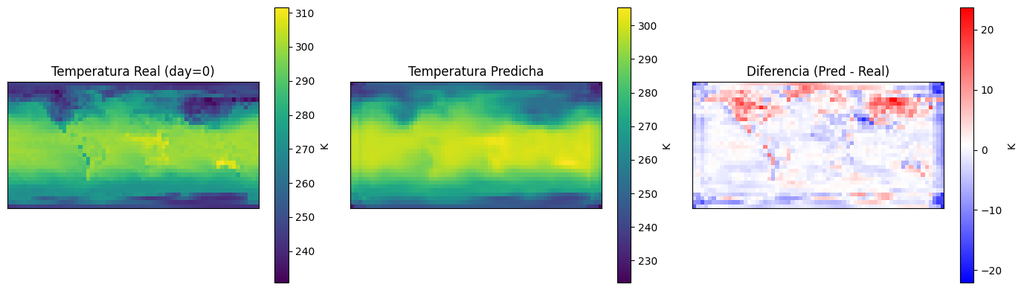

```python
compare_prediction(day_index=0, x_data=x_test_n, y_data=y_test, model=conv_model_c)
```

En la gráfica se puede observar una predicción similar a la obtenida con el modelo anterior, donde mejora un poco la identificación de zonas de temperaturas extremas o con características particulares por la geografía. Por ejemplo, se observa un poco más resaltado la zona de África y Australia con temperaturas más altas; la cordillera del Himalaya se encuentra un poco más sombreado con temperaturas más bajas; y finalmente, hay una leve identificación de la cordillera de los Andes pero de manera suavizada. En la gráfica de la diferencia entre el valor real y la predicción, se observa que mejora la sobreestimación para ciertas zonas, dando como resultado un color blanco. Por otra parte, las diferencias de zonas con temperaturas extremas persisten. Con esto tenemos que el modelo generaliza suavizando variaciones, pero no alcanza a detallar ciertos cambios, pese a la mejora en el RMSE global.

Seguidamente, se calcula el error a nivel de píxel.

```
pixel_rmse_c shape: (32, 64)
```

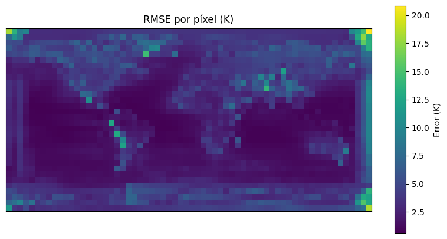

```python
#metrica a nivel pixel
pixel_rmse_c = np.mean((y_test - y_pred_c)**2, axis=0)
pixel_rmse_c = np.sqrt(pixel_rmse_c)
pixel_rmse_c = np.squeeze(pixel_rmse_c)

print("pixel_rmse_c shape:", pixel_rmse_c.shape)
plt.figure(figsize=(10, 5))
plt.imshow(pixel_rmse_c, origin='lower')
plt.title("RMSE por píxel (K)")
plt.colorbar(label="Error (K)")
plt.xticks([])
plt.yticks([])
plt.show()
```

El RMSE por píxel muestra una leve mejora en el modelo debido a que el error en zonas montañosas disminuyó con respecto al modelo anterior, obteniendo un error un poco más homogéneo. En particular, se mejora la predicción en zonas que en el modelo simple presentaban errores altos, como regiones montañosas o zonas polares. Sin embargo, se sigue observando colores más claros en estas zonas (mayor error).

Las mejoras del modelo pudieron ser por agregar más capas convolucionales con más filtros que permitieran el aprendizaje de aspectos globales y específicos, con el balance de la regularización L2 para la penalización de pesos grandes (reducir sobreajuste) y el dropout para evitar la adaptación demasiada de los datos. Con esto se obtuvo una adecuada generalización y la captación de patrones. Adicionalmente, el uso de Batch Normalization ayuda a estabilizar y acelerar el entrenamiento.

**Ejercicio 10** (1.5 puntos): Para intentar mejorar las predicciones vamos a implementar un modelo residual, más concretamente DenseNet [3]. Implementa, siguiendo lo visto en clase (y en su correspondiente notebook) el siguiente modelo (BN se corresponde con Batch Normalization):

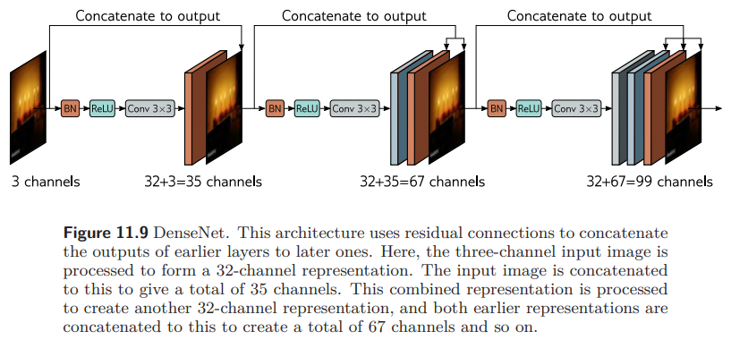

Puedes decidir que poner en la última capa, después del tercer bloque residual. En nuestro caso en vez de 3 canales de entrada recordad que tenemos 6. Intenta escribir el modelo de una forma compacta y funcional (guiate del modelo residual implementado en la práctica vista en clase). Entrena y evalua las predicciones en el periodo de test.

Primero se define una función que construye un bloque de tipo DenseNet, donde se concatenan las salidas con la entrada original del bloque. Esta arquitectura se caracteriza por crear conexiones densas entre capas, permitiendo que cada capa reciba como entrada no solo la salida de la capa anterior, sino también la de todas las anteriores. Esto ayuda a preservar la información original, evitar la desaparición del gradiente y facilitar el entrenamiento de modelos más profundos.

La función que se define a continuación primero aplica una normalización por lotes (Batch Normalization) para estabilizar el aprendizaje, luego una función de activación ReLU para introducir no linealidad, y finalmente una convolución que genera nuevas representaciones. Al concatenar estas nuevas características con la entrada inicial, se enriquece la representación sin perder información útil. Este tipo de esquema permite la reutilización de caracteristicas aprendidas.

```python
#bloque densenet
def dense_block(x, filters, kernel_size):

    out = layers.BatchNormalization()(x)
    out = layers.Activation('relu')(out)
    out = layers.Conv2D(filters=filters, kernel_size=kernel_size, padding='same')(out)

    # concatena la salida con la entrada
    x = layers.Concatenate()([x, out])
    return x
```

Luego se define la arquitectura del modelo DenseNet, partiendo de una entrada con 6 canales que representan las distintas variables predictoras espaciales.Como primer paso, se incluye una capa convolucional inicial con 32 filtros y activación ReLU para proyectar las 6 variables originales a un espacio de mayor dimensionalidad, facilitando el aprendizaje de patrones más complejos desde el inicio. Esta capa también actúa como una fase de expansión de características, donde se combinan los canales originales para obtener representaciones más abstractas. Luego, se aplican tres bloques DenseNet usando la función definida, donde cada uno normaliza, aplica una función de activación ReLU, realiza una convolución con 32 filtros, y finalmente concatena su salida con la entrada original del bloque. Finalmente, se añade una capa convolucional de salida con 1 solo filtro, que genera una predicción escalar por píxel en un mapa de forma (32, 64, 1). Se utiliza activación lineal debido a que se trata de un problema de regresión, donde se busca estimar la temperatura de superficie en cada punto del grid espacial.

```python
seed = 703
random.seed(seed)
np.random.seed(seed)
tf.random.set_seed(seed)

# modelo densenet
# entrada
inputs = layers.Input(shape=x_train_n.shape[1:])

# Capa de expansión de canales
x = layers.Conv2D(filters=32, kernel_size=3, padding='same', activation='relu')(inputs)

# bloques desenet
x = dense_block(x, filters=32, kernel_size=3)
x = dense_block(x, filters=32, kernel_size=3)
x = dense_block(x, filters=32, kernel_size=3)

# capa convolucional final
outputs = layers.Conv2D(filters=1, kernel_size=3, padding='same', activation='linear')(x)

# modelo
model_densenet = models.Model(inputs=inputs, outputs=outputs)

model_densenet.summary()
```

```
Model: "model"
__________________________________________________________________________________________________
 Layer (type)                Output Shape                 Param #   Connected to
==================================================================================================
 input_4 (InputLayer)        [(None, 32, 64, 6)]          0         []

 conv2d_8 (Conv2D)           (None, 32, 64, 32)           1760      ['input_4[0][0]']

 batch_normalization_4 (Bat  (None, 32, 64, 32)           128       ['conv2d_8[0][0]']
 chNormalization)

 activation (Activation)     (None, 32, 64, 32)           0         ['batch_normalization_4[0][0]'
                                                                    ]

 conv2d_9 (Conv2D)           (None, 32, 64, 32)           9248      ['activation[0][0]']

 concatenate (Concatenate)   (None, 32, 64, 64)           0         ['conv2d_8[0][0]',
                                                                     'conv2d_9[0][0]']

 batch_normalization_5 (Bat  (None, 32, 64, 64)           256       ['concatenate[0][0]']
 chNormalization)

 activation_1 (Activation)   (None, 32, 64, 64)           0         ['batch_normalization_5[0][0]'
                                                                    ]

 conv2d_10 (Conv2D)          (None, 32, 64, 32)           18464     ['activation_1[0][0]']

 concatenate_1 (Concatenate  (None, 32, 64, 96)           0         ['concatenate[0][0]',
 )                                                                   'conv2d_10[0][0]']

 batch_normalization_6 (Bat  (None, 32, 64, 96)           384       ['concatenate_1[0][0]']
 chNormalization)

 activation_2 (Activation)   (None, 32, 64, 96)           0         ['batch_normalization_6[0][0]'
                                                                    ]

 conv2d_11 (Conv2D)          (None, 32, 64, 32)           27680     ['activation_2[0][0]']

 concatenate_2 (Concatenate  (None, 32, 64, 128)          0         ['concatenate_1[0][0]',
 )                                                                   'conv2d_11[0][0]']

 conv2d_12 (Conv2D)          (None, 32, 64, 1)            1153      ['concatenate_2[0][0]']

==================================================================================================
Total params: 59073 (230.75 KB)
Trainable params: 58689 (229.25 KB)
Non-trainable params: 384 (1.50 KB)
__________________________________________________________________________________________________
```

Seguidamente, se compila y entrena el modelo.

```python
# Ajustamos un poco la learning rate de Adam
optimizer = tf.keras.optimizers.Adam(learning_rate=1e-3)

model_densenet.compile(optimizer=optimizer, loss='mse', metrics=['mse'])

history_densenet = model_densenet.fit(x_train_n, y_train, validation_split=0.2, epochs=50, batch_size=32,
    callbacks=[tf.keras.callbacks.EarlyStopping(monitor='val_loss', patience=5,restore_best_weights=True)])
```

Seguidamente se evalúa el modelo, para lo cual se hace la predicción, se obtiene el MSE, se calcula el RMSE, se visualiza la predicción del modelo y se calcula el error a nivel de píxel.

```python
# Predicciones
y_pred_densenet = model_densenet.predict(x_test_n)

# MSE global
mse_densenet = model_densenet.evaluate(x_test_n, y_test)[1]
print(f"MSE global: {mse_densenet:.4f}")

# RMSE global
rmse_densenet = mean_squared_error(y_test.flatten(), y_pred_densenet.flatten(), squared=False)
print(f"RMSE global: {rmse_densenet:.4f}")
```

```
MSE global: 8.9813
RMSE global: 2.9969
```

Los resultados muestran que el MSE y RMSE disminuyen con respecto al modelo convolucional complejo, pasando en el RMSE de 3.8 a 2.9. Esto quiere decir que en promedio hay una desviación de la predicción de 2.9°K, lo cual es un poco mejor que los anteriores modelos.

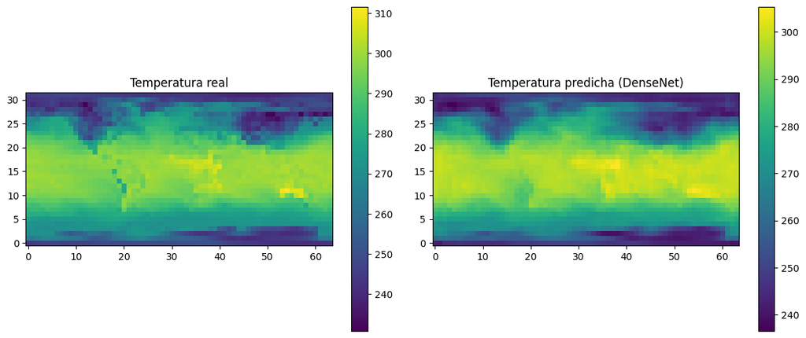

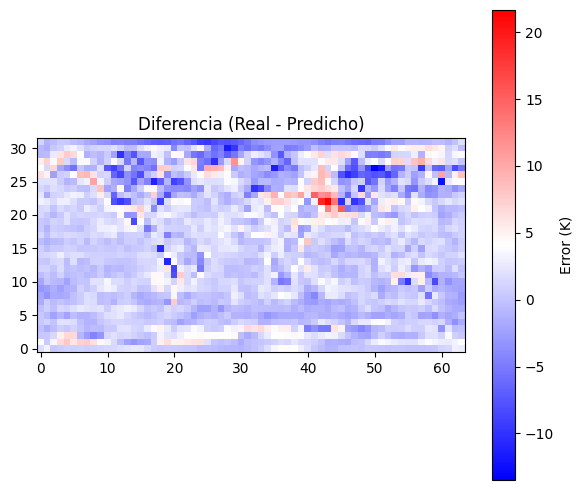

```python
dia = 0

plt.figure(figsize=(12, 5))

# Temperatura real
plt.subplot(1, 2, 1)
plt.imshow(y_test[dia, :, :, 0], origin='lower')
plt.title("Temperatura real")
plt.colorbar()

# Temperatura predicha
plt.subplot(1, 2, 2)
plt.imshow(y_pred_densenet[dia, :, :, 0], origin='lower')
plt.title("Temperatura predicha (DenseNet)")
plt.colorbar()

plt.tight_layout()
plt.show()

# diferencia entre predicción y real
plt.figure(figsize=(6, 5))
diff = y_test[dia, :, :, 0] - y_pred_densenet[dia, :, :, 0]
plt.imshow(diff, origin='lower', cmap='bwr')
plt.title("Diferencia (Real - Predicho)")
plt.colorbar(label='Error (K)')
plt.tight_layout()
plt.show()
```

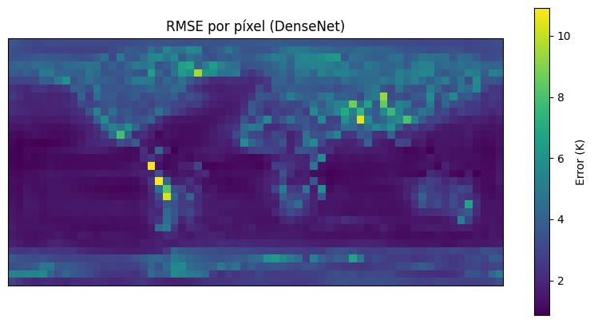

```python
# RMSE por píxel
pixel_mse_dense = np.mean((y_test - y_pred_densenet)**2, axis=0)
pixel_rmse_dense = np.sqrt(pixel_mse_dense)
pixel_rmse_dense = np.squeeze(pixel_rmse_dense)

plt.figure(figsize=(10, 5))
plt.imshow(pixel_rmse_dense, origin='lower')
plt.title("RMSE por píxel (DenseNet)")
plt.colorbar(label="Error (K)")
plt.xticks([]); plt.yticks([])
plt.show()
```

**Ejercicio 11** (1.5 puntos): Para terminar la práctica vamos a entrenar una arquitectura del tipo U-Net (como la vista en clase). Para ello primero vamos a modificar los datos de entrada y salida del modelo, ya que, aunque es posible, la U-Net fue diseñada en un principio para procesar imágenes cuadradas con un número de pixels proporcional a una potencia de 2. Para ello transformaremos tanto los predictores como el predictando de la siguente forma:

```python
x_data_unet, y_data_unet = x_data[:, :, :32, :], y_data[:, :, :32, :]
```

```python
print(f'X_unet shape: {x_data_unet.shape} | Y_unet shape: {y_data_unet.shape}')
```

```
X_unet shape: (14610, 32, 32, 6) | Y_unet shape: (14610, 32, 32, 1)
```

De esta forma nos centramos en el dominio que cubre América con un número de pixeles en la latitud y la longitud de $2^5=32$:

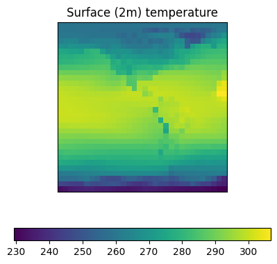

```python
plot_mean_subplots(data=y_data_unet, variable_dims=predictand_vars, figsize=(4, 4))
```

Recuerda que antes de entrenar el modelo es necesario volver a dividir en train y test y normalizar los datos. Podeis reutilizar el código de ejercicios anteriores

Primero se divide los datos en train y test teniendo en cuenta el orden temporal.

```python
n_samples = x_data_unet.shape[0]
train_size = int(n_samples * 0.8)

x_train_u = x_data_unet[:train_size]
y_train_u = y_data_unet[:train_size]
x_test_u  = x_data_unet[train_size:]
y_test_u  = y_data_unet[train_size:]

print(f"x_train shape: {x_train_u.shape} | y_train shape: {y_train_u.shape}")
print(f"x_test  shape: {x_test_u.shape}  | y_test  shape: {y_test_u.shape}")
```

```
x_train shape: (11688, 32, 32, 6) | y_train shape: (11688, 32, 32, 1)
x_test  shape: (2922, 32, 32, 6)  | y_test  shape: (2922, 32, 32, 1)
```

Luego se normalizan los datos x de train y test.

```python
x_train_un = np.empty_like(x_train_u, dtype=np.float32)
x_test_un = np.empty_like(x_test_u, dtype=np.float32)

for var_idx in range(x_train_u.shape[-1]):
    train_var = x_train_u[..., var_idx]
    test_var = x_test_u[..., var_idx]

    min_val = np.min(train_var)
    max_val = np.max(train_var)

    if max_val == min_val:
        x_train_un[..., var_idx] = 0
        x_test_un[..., var_idx] = 0
    else:
        x_train_un[..., var_idx] = (train_var - min_val) / (max_val - min_val)
        x_test_un[..., var_idx]  = (test_var - min_val) / (max_val - min_val)

print(x_train_un.shape, x_test_un.shape)
```

```
(11688, 32, 32, 6) (2922, 32, 32, 6)
```

Diseña y entrena una U-Net. En este caso el número de canales de entrada y salida no es el mismo, ten en cuenta esto. Se valorán de forma positiva variaciones con respecto a la presentada en clase. Entrena y evalua el modelo.

Primero se definen funciones auxiliares que permiten construir una arquitectura U-Net modular, favoreciendo un diseño más legible, escalable y mantenible, y facilitando su ajuste en parámetros como el número de filtros o la función de activación.

En primer lugar, la función conv_block aplica una convolución simple, seguida de normalización por lotes y la activación ReLU. Este bloque sirve como base para construir secciones profundas del modelo donde se procesan representaciones espaciales comprimidas.

Por su parte, la función encoder_block aplica una convolución, normalización y ReLU, seguidas de un MaxPooling, lo que reduce las dimensiones espaciales de la entrada. Esta función devuelve dos salidas: x, que representa la activación antes del MaxPooling (usada posteriormente como skip connection), y p, la salida tras el MaxPooling, que se utiliza como entrada al siguiente bloque del encoder. Este diseño permite reducir progresivamente la dimensionalidad espacial hasta alcanzar un espacio latente que codifica características globales.

Finalmente, la función decoder_block permite reconstruir la resolución espacial. Primero realiza un UpSampling (duplicando la resolución), concatena con el resultado del encoder correspondiente mediante una skip connection, y luego aplica una convolución, normalización y activación ReLU. Esta estructura es clave para recuperar los detalles espaciales preservados por el encoder, permitiendo una reconstrucción más precisa de la imagen de salida.

```python
def conv_block(x, filters, kernel_size):
    x = layers.Conv2D(filters=filters, kernel_size=kernel_size, padding='same')(x)
    x = layers.BatchNormalization()(x)
    x = layers.Activation('relu')(x)
    return x

def encoder_block(x, filters, kernel_size):
    x = layers.Conv2D(filters=filters, kernel_size=kernel_size, padding='same')(x)
    x = layers.BatchNormalization()(x)
    x = layers.Activation('relu')(x)
    p = layers.MaxPooling2D((2, 2))(x)
    return x, p

def decoder_block(x, skip_connection, filters, kernel_size):
    x = layers.UpSampling2D((2, 2))(x)
    x = layers.Concatenate()([x, skip_connection])
    x = layers.Conv2D(filters=filters, kernel_size=kernel_size, padding='same')(x)
    x = layers.BatchNormalization()(x)
    x = layers.Activation('relu')(x)
    return x
```

Seguidamente, se define la arquitectura del modelo U-Net utilizando las funciones previas. En primer lugar, se especifica la forma de entrada, correspondiente a imágenes de 32x32 píxeles con 6 canales. Luego, se añaden dos bloques de encoder que permiten reducir progresivamente las dimensiones espaciales de la entrada, mientras se incrementa la profundidad (número de filtros), extrayendo características cada vez más abstractas. Luego, en "Conv" es donde se procesan las representaciones espaciales comprimidas mediante una capa convolucional más profunda. Finalmente, se construye el decoder, que consiste también en dos bloques, encargados de recuperar las dimensiones espaciales originales mediante operaciones de upsampling y skip connections desde el encoder, lo cual permite conservar información espacial de baja y alta escala. El modelo finaliza con una capa convolucional de 1 filtro con activación lineal, generando una salida escalar por cada píxel, correspondiente a la predicción de temperatura.

```python
seed = 703
random.seed(seed)
np.random.seed(seed)
tf.random.set_seed(seed)

input_shape = x_train_un.shape[1:]
inputs = layers.Input(shape=input_shape)

# Encoder
x1, p1 = encoder_block(inputs, filters=32, kernel_size=3)
x2, p2 = encoder_block(p1, filters=64, kernel_size=3)

# Conv
bottleneck = conv_block(p2, filters=128, kernel_size=3)

# Decoder
d2 = decoder_block(bottleneck, x2, filters=64, kernel_size=3)
d1 = decoder_block(d2, x1, filters=32, kernel_size=3)

# Salida
outputs = layers.Conv2D(filters=1, kernel_size=1, activation='linear')(d1)

# Modelo
model_unet = models.Model(inputs=inputs, outputs=outputs)
model_unet.summary()
```

```
Model: "model_1"
__________________________________________________________________________________________________
 Layer (type)                Output Shape                 Param #   Connected to
==================================================================================================
 input_5 (InputLayer)        [(None, 32, 32, 6)]          0         []

 conv2d_13 (Conv2D)          (None, 32, 32, 32)           1760      ['input_5[0][0]']

 batch_normalization_7 (Bat  (None, 32, 32, 32)           128       ['conv2d_13[0][0]']
 chNormalization)

 activation_3 (Activation)   (None, 32, 32, 32)           0         ['batch_normalization_7[0][0]'
                                                                    ]

 max_pooling2d (MaxPooling2  (None, 16, 16, 32)           0         ['activation_3[0][0]']
 D)

 conv2d_14 (Conv2D)          (None, 16, 16, 64)           18496     ['max_pooling2d[0][0]']

 batch_normalization_8 (Bat  (None, 16, 16, 64)           256       ['conv2d_14[0][0]']
 chNormalization)

 activation_4 (Activation)   (None, 16, 16, 64)           0         ['batch_normalization_8[0][0]'
                                                                    ]

 max_pooling2d_1 (MaxPoolin  (None, 8, 8, 64)             0         ['activation_4[0][0]']
 g2D)

 conv2d_15 (Conv2D)          (None, 8, 8, 128)            73856     ['max_pooling2d_1[0][0]']

 batch_normalization_9 (Bat  (None, 8, 8, 128)            512       ['conv2d_15[0][0]']
 chNormalization)

 activation_5 (Activation)   (None, 8, 8, 128)            0         ['batch_normalization_9[0][0]'
                                                                    ]

 up_sampling2d (UpSampling2  (None, 16, 16, 128)          0         ['activation_5[0][0]']
 D)

 concatenate_3 (Concatenate  (None, 16, 16, 192)          0         ['up_sampling2d[0][0]',
```

[output cut: 16 more lines]

```
 conv2d_17 (Conv2D)          (None, 32, 32, 32)           27680     ['concatenate_4[0][0]']

 batch_normalization_11 (Ba  (None, 32, 32, 32)           128       ['conv2d_17[0][0]']
 tchNormalization)

 activation_7 (Activation)   (None, 32, 32, 32)           0         ['batch_normalization_11[0][0]
                                                                    ']

 conv2d_18 (Conv2D)          (None, 32, 32, 1)            33        ['activation_7[0][0]']

==================================================================================================
Total params: 233761 (913.13 KB)
Trainable params: 233121 (910.63 KB)
Non-trainable params: 640 (2.50 KB)
__________________________________________________________________________________________________
```

Se compila y entrena el modelo con el optimizador "Adam" con el learning_rate por defecto y demás parámetros de los modelos anteriores.

```python
model_unet.compile(optimizer='adam', loss='mse', metrics=['mse'])

history_unet = model_unet.fit(x_train_un, y_train_u, validation_split=0.2, epochs=50, batch_size=32,
    callbacks=[tf.keras.callbacks.EarlyStopping(monitor='val_loss', patience=5, restore_best_weights=True)])
```

Se realiza la predicción y la evaluación con el MSE y RMSE del modelo.

```python
y_pred_unet = model_unet.predict(x_test_un)

mse_unet = model_unet.evaluate(x_test_un, y_test_u)[1]
rmse_unet = mean_squared_error(y_test_u.flatten(), y_pred_unet.flatten(), squared=False)

print(f"MSE: {mse_unet:.4f} | RMSE: {rmse_unet:.4f}")
```

```
MSE: 4.8932 | RMSE: 2.2121
```

Los resultados del MSE y RMSE con respecto a los modelos anteriores evidencian una reduccion significativa, mostrando que en promedio hay una desviación de la predicción de 2.2°K. Esta mejora puede atribuirse a la capacidad de la U-Net para combinar información local y global, gracias al uso de skip connections entre las capas del encoder y del decoder. Estas conexiones permiten que el modelo recupere información espacial fina, lo cual es especialmente útil en tareas de segmentación o predicción espacial como esta, donde se requiere precisión por píxel.

A continuación, se hace una comparación visual entre la temperatura de superficie real y la predicha por el modelo U-Net. Esta visualización permite evaluar si el modelo ha aprendido patrones espaciales coherentes en la predicción.

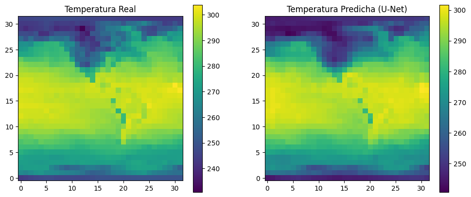

```python
plt.figure(figsize=(12, 5))
plt.subplot(1, 2, 1)
plt.imshow(y_test_u[0, :, :, 0], origin='lower')
plt.title("Temperatura Real"); plt.colorbar()

plt.subplot(1, 2, 2)
plt.imshow(y_pred_unet[0, :, :, 0], origin='lower')
plt.title("Temperatura Predicha (U-Net)"); plt.colorbar()
plt.show()
```

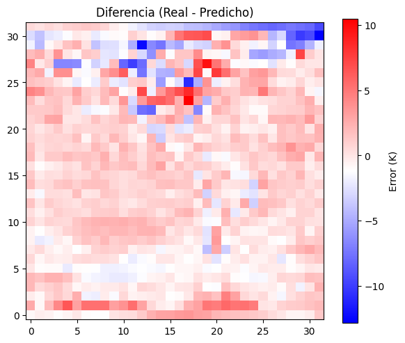

```python
# Día a visualizar
dia = 0

# Diferencia entre la real y la predicha
diff = y_test_u[dia, :, :, 0] - y_pred_unet[dia, :, :, 0]

plt.figure(figsize=(6, 5))
plt.imshow(diff, origin='lower', cmap='bwr')
plt.title("Diferencia (Real - Predicho)")
plt.colorbar(label="Error (K)")
plt.tight_layout()
plt.show()
```

La gráfica de la temperatura predicha muestra un patrón espacial muy similar al observado en los datos reales, lo que indica que el modelo ha aprendido correctamente la distribución espacial de la variable objetivo. En la predicción se evidencia la identificación de regiones con temperaturas extremas, como la cordillera de los Andes, con un color azul representando temperaturas más frías. En los modelos anteriores esta predicción no era tan clara y detallada, sino que tendía a suavizar la predicción en esta zona.

Finalmente, se calcula el RMSE promedio por píxel a lo largo del tiempo para observar las zonas geográficas con mayor error. Esto permite evaluar la capacidad espacial del modelo para capturar patrones complejos.

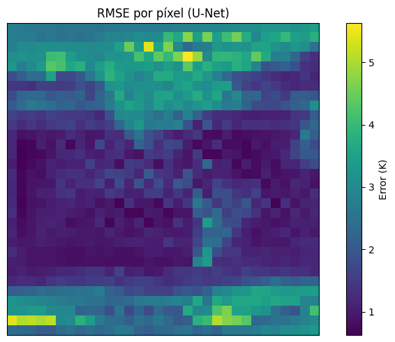

```python
# Cálculo del RMSE por píxel
pixel_mse_unet = np.mean((y_test_u - y_pred_unet)**2, axis=0)
pixel_rmse_unet = np.sqrt(pixel_mse_unet)
pixel_rmse_unet = np.squeeze(pixel_rmse_unet)

# Visualización
plt.figure(figsize=(8, 5))
plt.imshow(pixel_rmse_unet, origin='lower')
plt.title("RMSE por píxel (U-Net)")
plt.colorbar(label="Error (K)")
plt.xticks([]); plt.yticks([])
plt.tight_layout()
plt.show()
```

La gráfica muestra que el error por píxel mejora con respecto a modelos anteriores, evidenciando que el modelo U-Net es capaz de detectar patrones geográficos específicos, como los asociados a la cordillera de los Andes, sin necesidad de suavizar excesivamente la predicción, como ocurría antes. El error en estas zonas se reduce, lo que sugiere una mejor capacidad del modelo para manejar variaciones abruptas.

No obstante, todavía se observan algunas regiones con errores ligeramente más altos, especialmente en el norte del continente, posiblemente debido a una menor presencia de patrones estacionales definidos. En general, el modelo generaliza bien, logrando una distribución más homogénea del error y mejores métricas tanto globales como locales en comparación con las arquitecturas anteriores.

### Referencias

**[1]** Rasp, S., Dueben, P. D., Scher, S., Weyn, J. A., Mouatadid, S., & Thuerey, N. (2020). WeatherBench: a benchmark data set for data‐driven weather forecasting. Journal of Advances in Modeling Earth Systems, 12(11), e2020MS002203.

**[2]** Rasp, S., Hoyer, S., Merose, A., Langmore, I., Battaglia, P., Russell, T., ... & Sha, F. (2024). WeatherBench 2: A benchmark for the next generation of data‐driven global weather models. Journal of Advances in Modeling Earth Systems, 16(6), e2023MS004019.

**[3]** Huang, G., Liu, Z., Van Der Maaten, L., & Weinberger, K. Q. (2017). Densely connected convolutional networks. In Proceedings of the IEEE conference on computer vision and pattern recognition (pp. 4700-4708).

**[4]** Prince, S. J. (2023). *Understanding deep learning*. MIT press.